# Differences between age components of projections

# Introduction

The most recent ONS period life expectancy projections for Scotland for 2018 are lower than for 2016, which were lower than for 2014. These overall life expectancy projections are made up of changes to age-specific mortality rate projections, which have also been changed. This short paper will show how these age-specific mortality projections have changed over these last three modifications.

```r
pacman::p_load(here, tidyverse, readxl)
```

From here https://www.ons.gov.uk/peoplepopulationandcommunity/birthsdeathsandmarriages/lifeexpectancies/datasets/expectationoflifeprincipalprojectionscotland

Downloaded to data/ons_projections/scotland

2018 projection, Scotland https://www.ons.gov.uk/file?uri=%2fpeoplepopulationandcommunity%2fbirthsdeathsandmarriages%2flifeexpectancies%2fdatasets%2fexpectationoflifeprincipalprojectionscotland%2f2018based/scppp18ex.xls

2016 projection, Scotland https://www.ons.gov.uk/file?uri=%2fpeoplepopulationandcommunity%2fbirthsdeathsandmarriages%2flifeexpectancies%2fdatasets%2fexpectationoflifeprincipalprojectionscotland%2f2016based/wscoprincipal16.xls

2014 projection, Scotland https://www.ons.gov.uk/file?uri=%2fpeoplepopulationandcommunity%2fbirthsdeathsandmarriages%2flifeexpectancies%2fdatasets%2fexpectationoflifeprincipalprojectionscotland%2f2014based/wscoprincipal14.xls

2012 projection, Scotland https://www.ons.gov.uk/file?uri=%2fpeoplepopulationandcommunity%2fbirthsdeathsandmarriages%2flifeexpectancies%2fdatasets%2fexpectationoflifeprincipalprojectionscotland%2f2012based/wscoprincipal12exr.xls

```r
proj_2018_males <- read_excel(path = here("data", "ons_projections", "scotland", "scppp18ex.xls"),
                        sheet = "Males period ex", skip = 9

                          ) %>% slice(-1)
proj_2018_females <- read_excel(path = here("data", "ons_projections", "scotland", "scppp18ex.xls"),
                        sheet = "Females period ex", skip = 9

                          ) %>% slice(-1)
proj_2016_males <- read_excel(path = here("data", "ons_projections", "scotland", "wscoprincipal16.xls"),
                        sheet = "Males period ex", skip = 9

                          ) %>% slice(-1)
proj_2016_females <- read_excel(path = here("data", "ons_projections", "scotland", "wscoprincipal16.xls"),
                        sheet = "Females period ex", skip = 9

                          ) %>% slice(-1)
proj_2014_males <- read_excel(path = here("data", "ons_projections", "scotland", "wscoprincipal14.xls"),
                        sheet = "Males period ex", skip = 9

                          ) %>% slice(-1)
proj_2014_females <- read_excel(path = here("data", "ons_projections", "scotland", "wscoprincipal14.xls"),
                        sheet = "Females period ex", skip = 9

                          ) %>% slice(-1)
proj_2012_males <- read_excel(path = here("data", "ons_projections", "scotland", "wscoprincipal12exr.xls"),
                        sheet = "Males Period ex", skip = 10

                          ) %>% slice(-1)
proj_2012_females <- read_excel(path = here("data", "ons_projections", "scotland", "wscoprincipal12exr.xls"),
                        sheet = "Females Period ex", skip = 10

                          ) %>% slice(-1)
```

Now tidying, gathering, and combining

```r
all_projections <- bind_rows(
proj_2012_females %>%
  rename(age = `(years)`) %>%
  gather(-age, key = "year", value = "ex") %>%
  mutate(sex = "female", projection = "2012 projection"),
proj_2012_males %>%
  rename(age = `(years)`) %>%
  gather(-age, key = "year", value = "ex") %>%
  mutate(sex = "male", projection = "2012 projection"),
proj_2014_males %>%
  rename(age = `Attained age (years)`) %>%
  gather(-age, key = "year", value = "ex") %>%
  mutate(sex = "male", projection = "2014 projection"),
proj_2014_females %>%
  rename(age = `Attained age (years)`) %>%
  gather(-age, key = "year", value = "ex") %>%
  mutate(sex = "female", projection = "2014 projection"),
proj_2016_males %>%
  rename(age = `Attained age (years)`) %>%
  gather(-age, key = "year", value = "ex") %>%
  mutate(sex = "male", projection = "2016 projection"),
proj_2016_females %>%
  rename(age = `Attained age (years)`) %>%
  gather(-age, key = "year", value = "ex") %>%
  mutate(sex = "female", projection = "2016 projection"),
proj_2018_males %>%
  rename(age = `Attained age (years)`) %>%
  gather(-age, key = "year", value = "ex") %>%
  mutate(sex = "male", projection = "2018 projection"),
proj_2018_females %>%
  rename(age = `Attained age (years)`) %>%
  gather(-age, key = "year", value = "ex") %>%
  mutate(sex = "female", projection = "2018 projection")
) %>%
  mutate(year = as.numeric(year))
all_projections
```

| age | year | ex | sex | projection |
| --- | --- | --- | --- | --- |
| 0 | 1981 | 75.4 | female | 2012 projection |
| 1 | 1981 | 75.2 | female | 2012 projection |
| 2 | 1981 | 74.3 | female | 2012 projection |
| 3 | 1981 | 73.3 | female | 2012 projection |
| 4 | 1981 | 72.3 | female | 2012 projection |
| 5 | 1981 | 71.3 | female | 2012 projection |
| 6 | 1981 | 70.3 | female | 2012 projection |
| 7 | 1981 | 69.4 | female | 2012 projection |
| 8 | 1981 | 68.4 | female | 2012 projection |
| 9 | 1981 | 67.4 | female | 2012 projection |

[output cut: 990 more lines]

Now to visualise

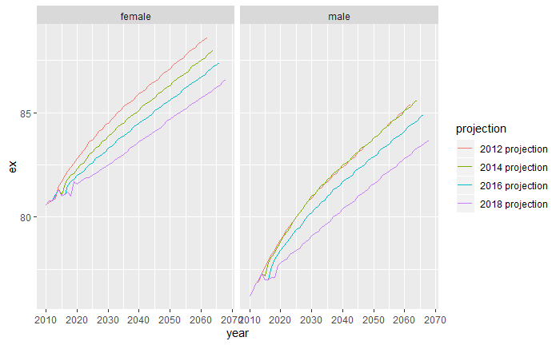

```r
all_projections %>%
  filter(age == 0) %>%
  filter(year >= 2010) %>%
  ggplot(aes(x = year, y = ex, colour = projection, group = projection)) +
  geom_line() +
  facet_wrap(~sex)
```

And now conditional

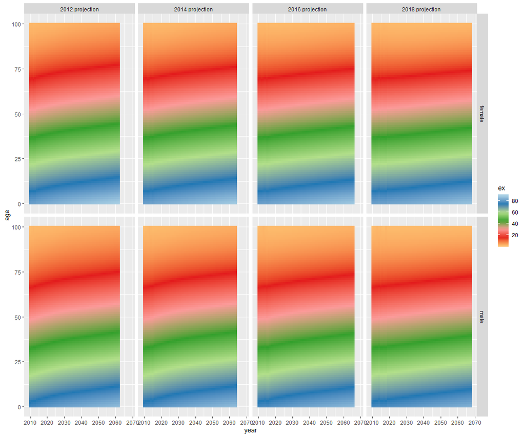

```r
all_projections %>%
  filter(year >= 2010) %>%
  ggplot(aes(x = year, age, fill = ex)) +
  geom_tile() +
  facet_grid(sex ~ projection) +
  scale_fill_distiller(palette = "Paired")
```

And now differences between two consecutive projections

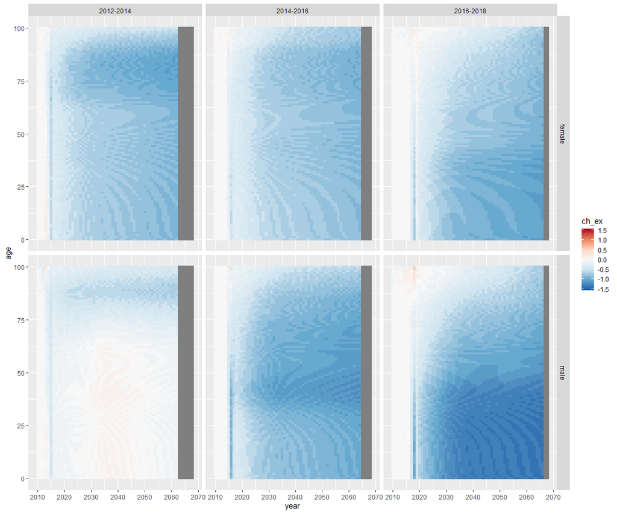

```r
all_projections %>%
  spread(projection, ex) %>%
  mutate(
    `2012-2014` = `2014 projection` - `2012 projection`,
    `2014-2016` = `2016 projection` - `2014 projection`,
    `2016-2018` = `2018 projection` - `2016 projection`
  ) %>%
  select(age, year, sex, `2012-2014`:`2016-2018`) %>%
  gather(key = "Comparison", value= "ch_ex", `2012-2014`:`2016-2018`) %>%
  filter(year >= 2010) %>%
  ggplot(aes(x = year, age, fill = ch_ex)) +
  geom_tile() +
  facet_grid(sex ~ Comparison) +
  scale_fill_distiller(palette = "RdBu", limits = c(-1.5, 1.5))
```

I want to check the % change is as expected

```r
all_projections %>%
  filter(age == 0) %>%
  filter(projection == "2018 projection") %>%
  group_by(sex) %>% arrange(year) %>%
  mutate(r_e0 = (ex - lag(ex)) / lag(ex)) %>%
  filter(year >= 2020) %>%
  ggplot(aes(x = year, y = r_e0, colour = sex, group = sex)) +
  geom_line()

all_projections %>%
  filter(age == 0) %>%
  filter(projection == "2018 projection") %>%
  group_by(sex) %>% arrange(year) %>%
  mutate(d_e0 = ex - lag(ex)) %>%
  filter(year >= 2020) %>%
  ggplot(aes(x = year, y = d_e0, colour = sex, group = sex)) +
  geom_line()
```

[output not shown]

The improvement rates are as applied to individual ages, then e_x is projected from these presumed changes.

But the change in e0 can be approximated from this.

- Effect of adding 2018 year to this
- Recommendation to do this for next year too.
- Rapid downgrading of last few successive mortality projections suggests an approach more responsive to new evidence may be needed.